# R Notebook

### Base Plotting System

The Core Plotting Functions

graphics: plot, hist, boxplot

grDevices: X11, PDF, PostScript, PNG

The Lattice Plotting System

lattice: xyplot, bwplot, levelplot

### Base Graphics

- initialize a new plot
- annotate an existing plot

?par : help page so useful

```r
?par
```

#### Histogram

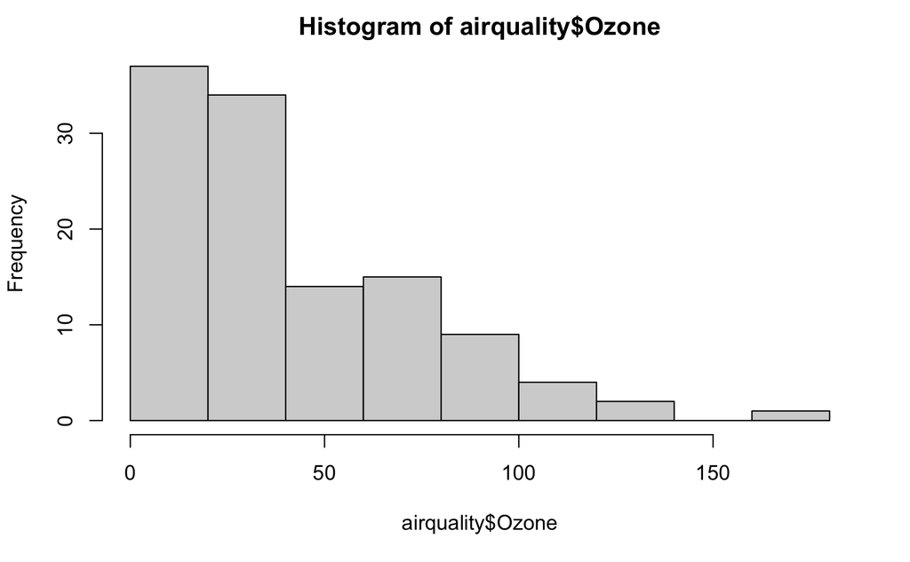

```r
library(datasets)

hist(airquality$Ozone)
```

#### Scatterplot

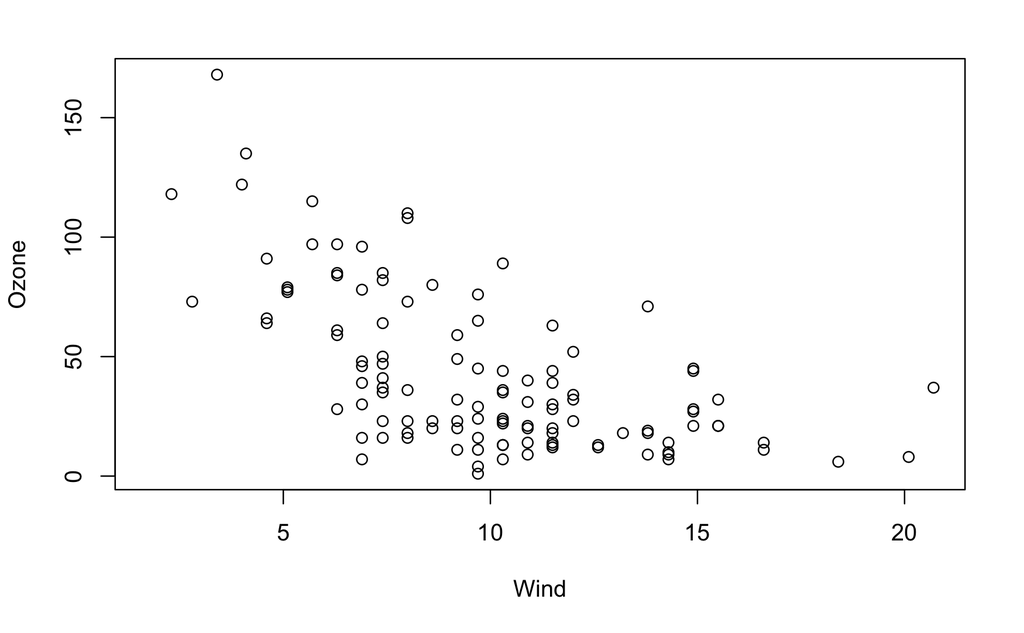

```r
with(airquality, plot(Wind, Ozone))
```

#### Boxplot

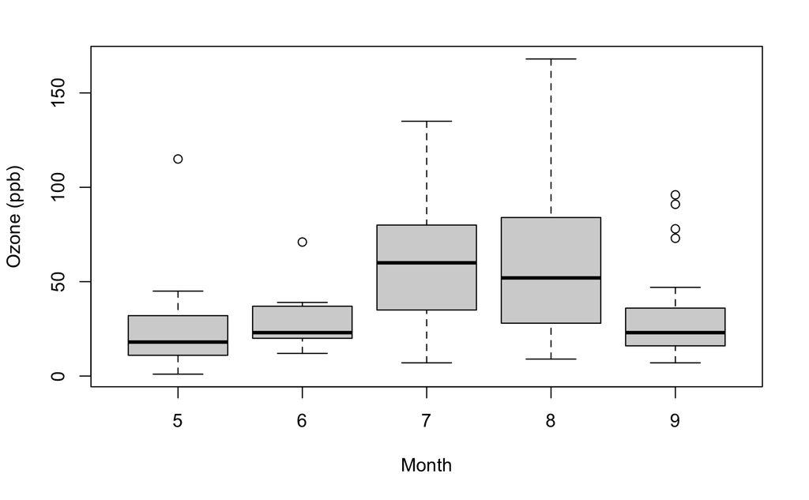

```r
airquality <- transform(airquality, Month = factor(Month))

boxplot(Ozone ~ Month, airquality, xlab = "Month", ylab = "Ozone (ppb)")
```

#### Important Base Graphics Paraneters

- pch: plotting symbol (default is circle)
- lty: line type (default is solid line)
- lwd: line width
- col: plotting color. colors() function gives you a vector of colors
- xlab: x-axis label
- ylab: y-axis label
- par(): is used to specify global graphics parameters that affect all plots in an R session.
  - las: orientation of the axis labels
  - bg: background color
  - mar: margin size
  - oma: outer margin size
  - mfrow: number of plots per row
  - mfcol: number of plots per collumn

```r
par("lty")
```

```
[1] "solid"
```

```r
par("col")
```

```
[1] "black"
```

```r
par("pch")
```

```
[1] 1
```

```r
par("bg")
```

```
[1] "white"
```

```r
par("mfrow")
```

```
[1] 1 1
```

```r
par("mar")
```

```
[1] 5.1 4.1 2.1 2.1
```

#### Base plotting functions

plot: makes a scatterplot or another type of plot depending on class of the object lines: add a line points: add points text: add text labels title: add annotations, title, subtitle, mtext: add arbitrary text to the margins axis: adding axis ticks/labels

#### base plot with annotations

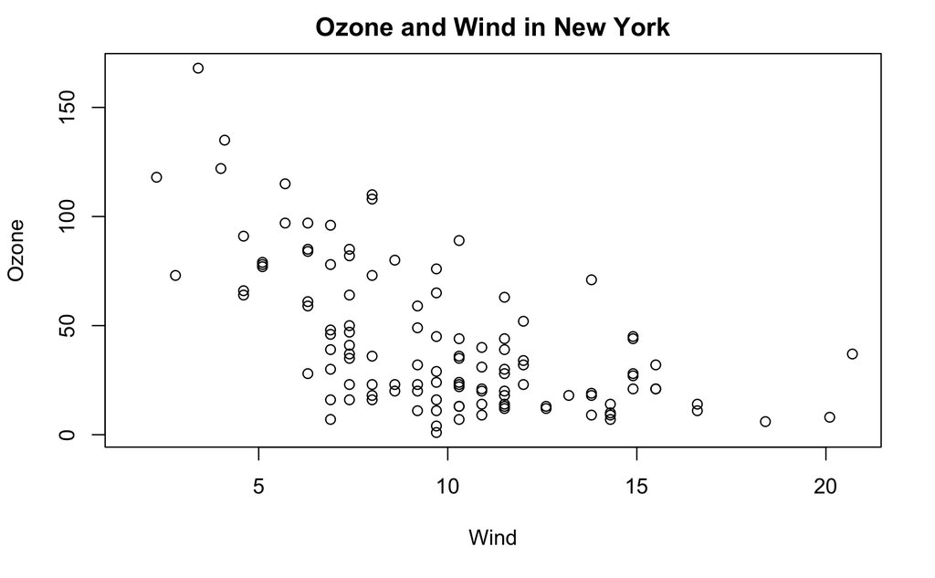

```r
library(datasets)

with(airquality, plot(Wind, Ozone))
title(main = "Ozone and Wind in New York")
```

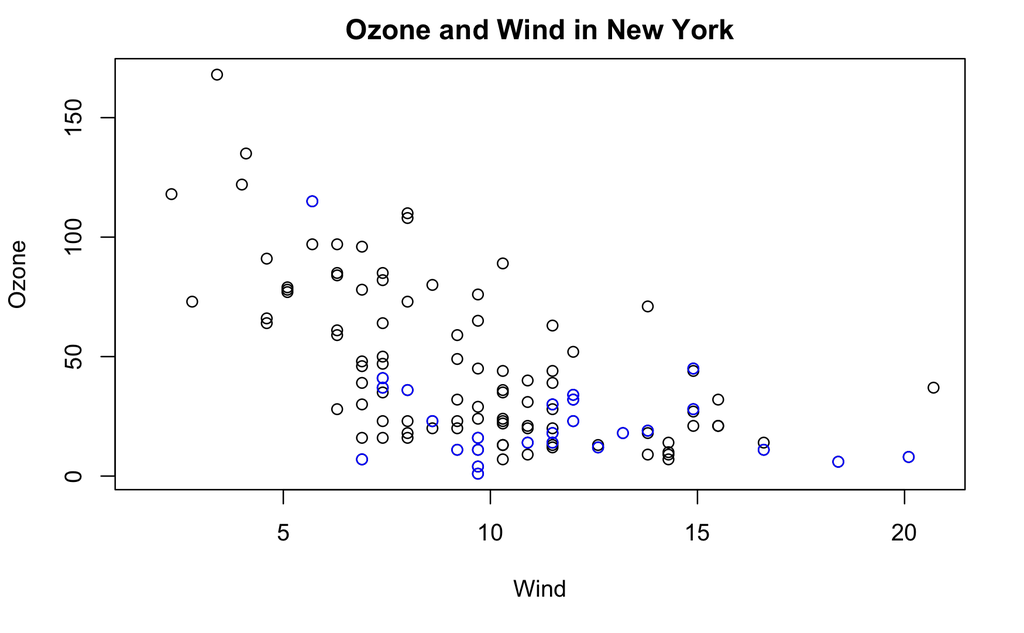

```r
### Here subset of data is colored blue

with(airquality, plot(Wind, Ozone, main = "Ozone and Wind in New York"))
with(subset(airquality, Month == 5), points(Wind, Ozone, col = "blue"))
```

type arguments

n: no plotting

```r
### Here subset of data is coloerd blue and red

with(airquality, plot(Wind, Ozone, main = "Ozone and Wind in New York",
     type = "n"))
with(subset(airquality, Month == 5), points(Wind, Ozone, col = "blue"))
```

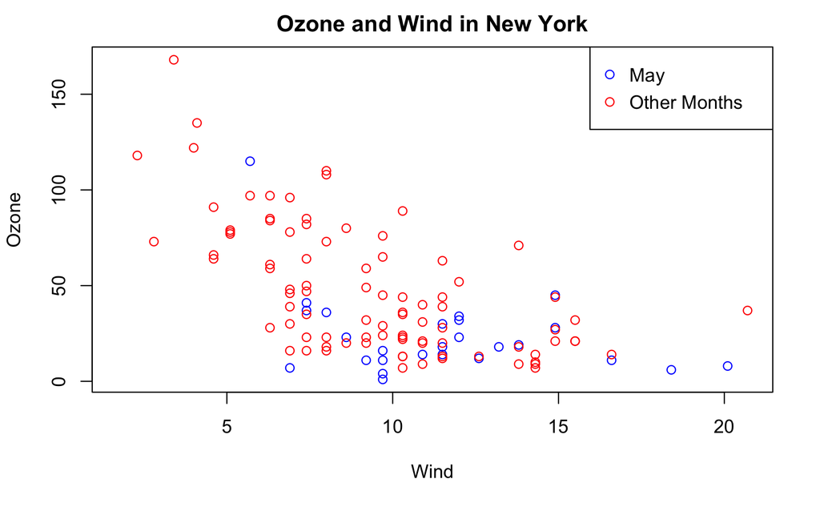

```r
with(subset(airquality, Month != 5), points(Wind, Ozone, col = "red"))
legend("topright", pch = 1, col = c("blue", "red"),
       legend = c("May", "Other Months"))
```

### Plot with Regression line

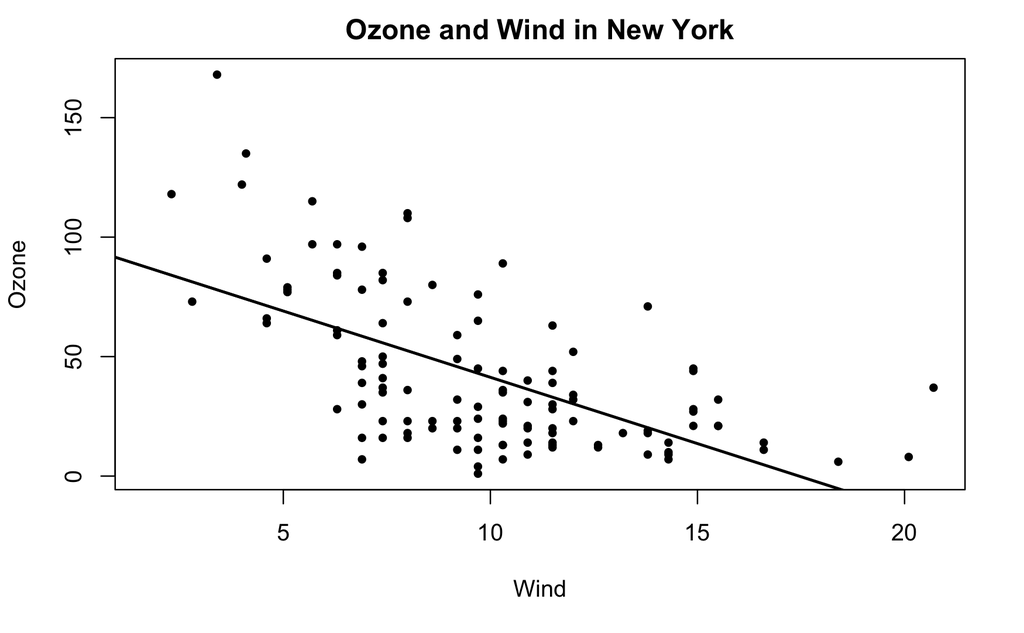

```r
with(airquality, plot(Wind, Ozone,
                      main = "Ozone and Wind in New York",
                      pch = 20))
model <- lm(Ozone ~ Wind, airquality)
abline(model, lwd = 2)
```

#### Multiple Base Plots

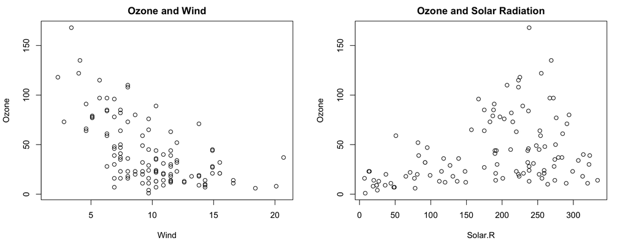

```r
par(mfrow = c(1, 2))

with(airquality, {plot(Wind, Ozone,
                      main = "Ozone and Wind")
    plot(Solar.R, Ozone, main = "Ozone and Solar Radiation")})
```

```r
NA
NA
```

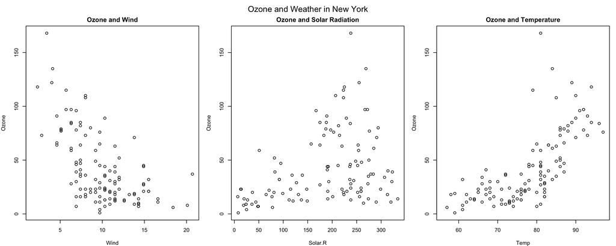

```r
par(mfrow = c(1, 3), mar = c(4, 4, 2, 1), oma = c(0, 0, 2, 0))

with(airquality, {
    plot(Wind, Ozone, main = "Ozone and Wind")
    plot(Solar.R, Ozone, main = "Ozone and Solar Radiation")
    plot(Temp, Ozone, main = "Ozone and Temperature")
    mtext("Ozone and Weather in New York", outer = TRUE)
    })
```

```r
NA
```

##### Summary

Plotting occurs in two stages: * Creation of a plot * Annotation of a plot (adding lines, points, text, legends)

##### Some Examples

```r
x = rnorm(100)
y = rnorm(100)
z = rnorm(100)
```

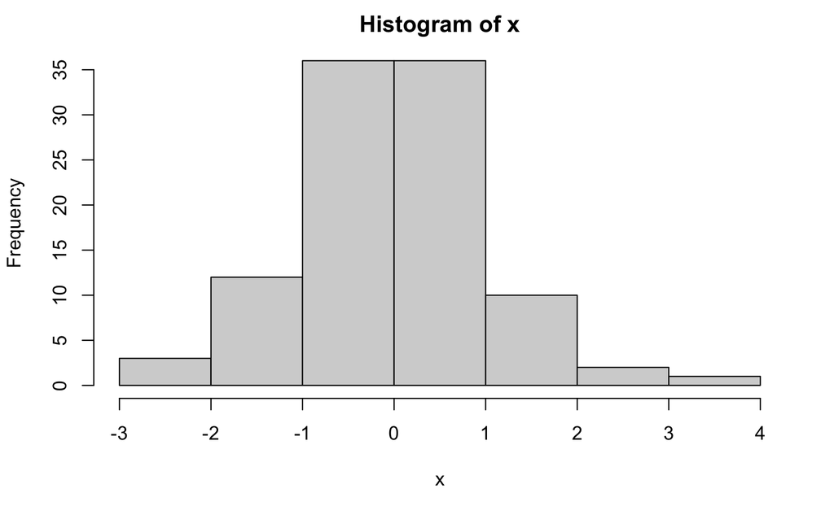

```r
hist(x)
```

pch: symbols

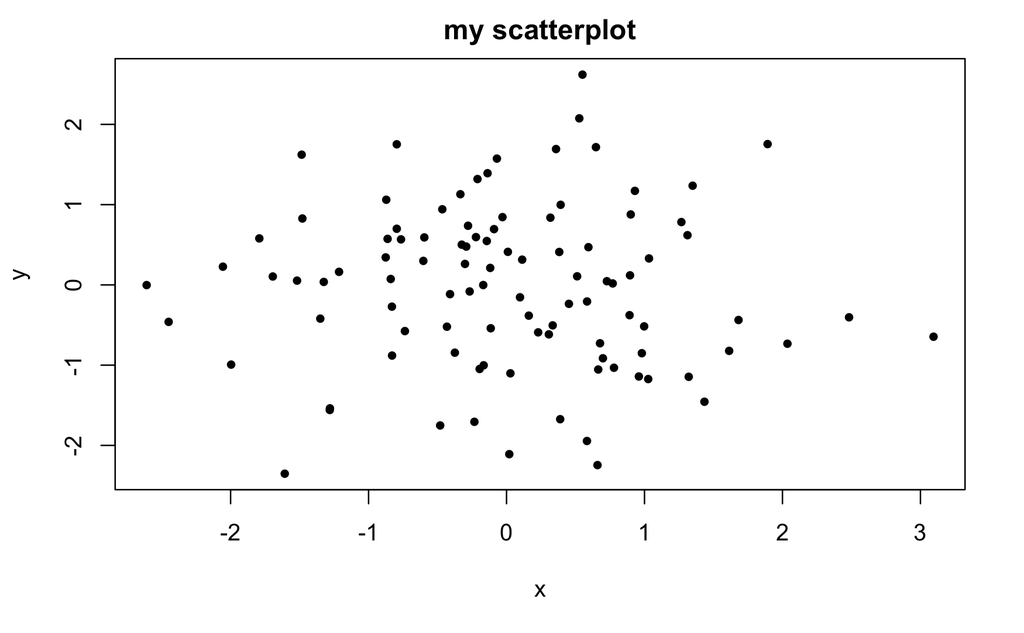

```r
plot(x, y,  pch = 20)

title("my scatterplot")
```

mar: margin size for each side c(bottom, left, top, right)

```r
plot(x, y,  pch = 20,
     mar = c(1, 1, 4, 4))

title("my scatterplot")
```

```r
text(-2, -2, "Label")
legend("topleft", legend = "Data", pch = 20)
```

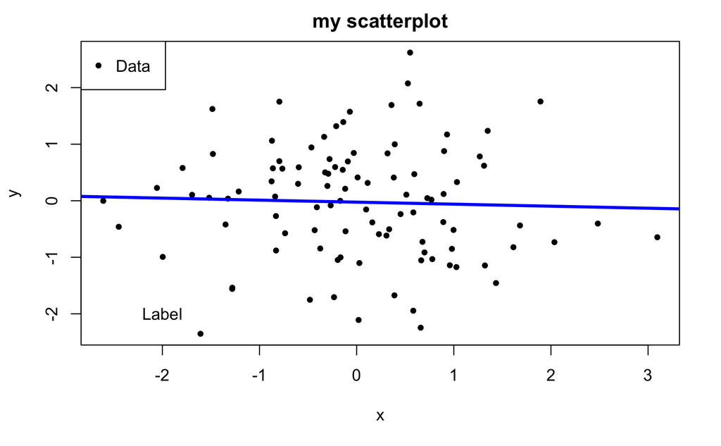

```r
fit <- lm(y ~ x)
abline(fit, lwd = 3, col = "blue")
```

```r
plot(x, y, xlab = "Weight", ylab = "Height",
     main = "Scatterplot", pch = 20)
legend("topright", legend = "Data", pch = 20)
```

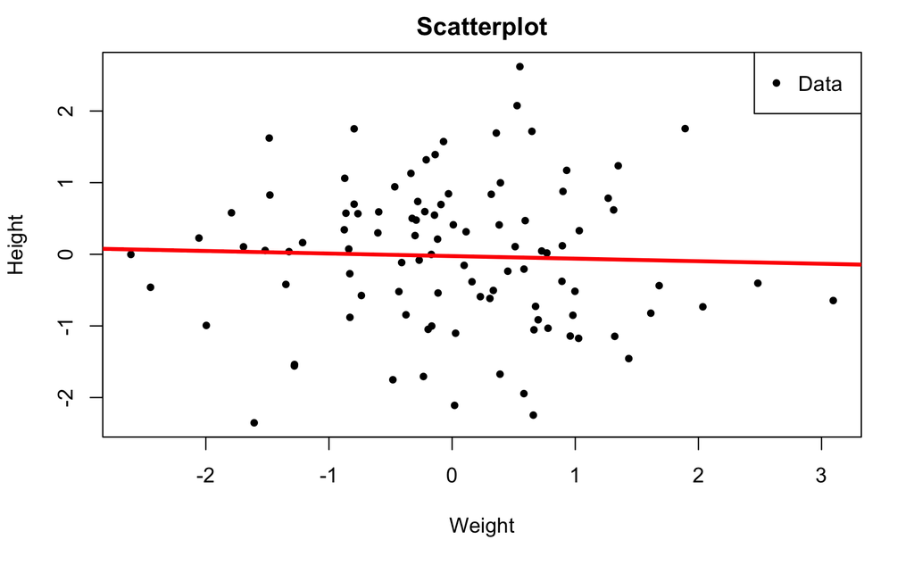

```r
abline(fit, lwd = 3, col = "red")
```

```r
z <- rpois(100, 2)
par(mfrow = c(2, 1))

plot(x, y, pch = 20)
plot(x, z, pch = 19)
```

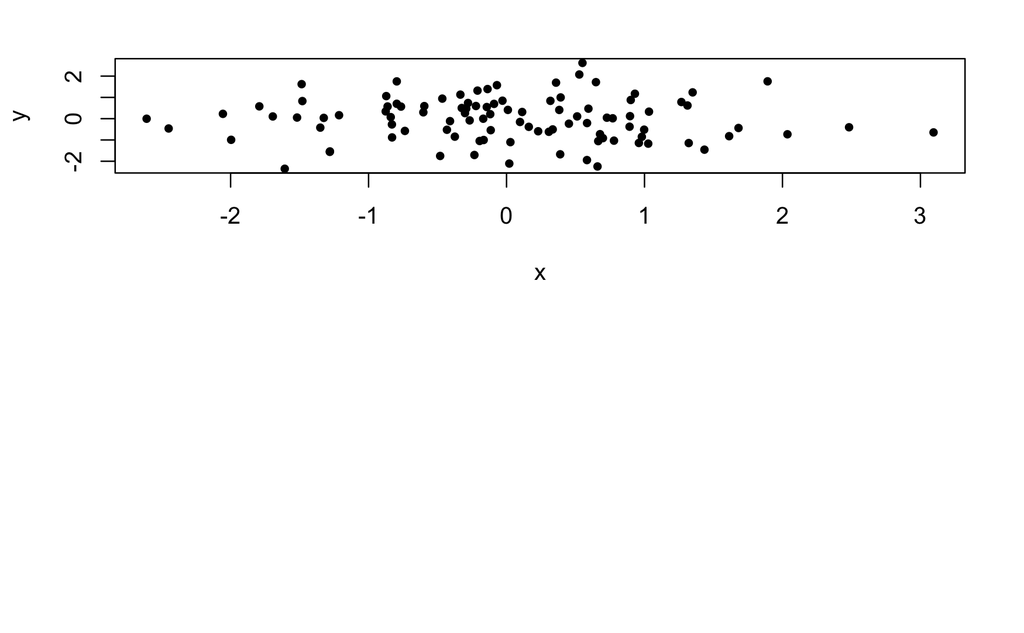

```r
par(mar = c(1, 2, 1, 1))
```

```r
x <- rnorm(100)
y <- x + rnorm(100)
g <- gl(2, 50, labels = c("Male", "Female"))
str(g)
```

```
 Factor w/ 2 levels "Male","Female": 1 1 1 1 1 1 1 1 1 1 ...
```

```r
plot(x, y, type = "n")
points(x[g == "Male"], y[g == "Male"], col = "blue", pch = 20)
```

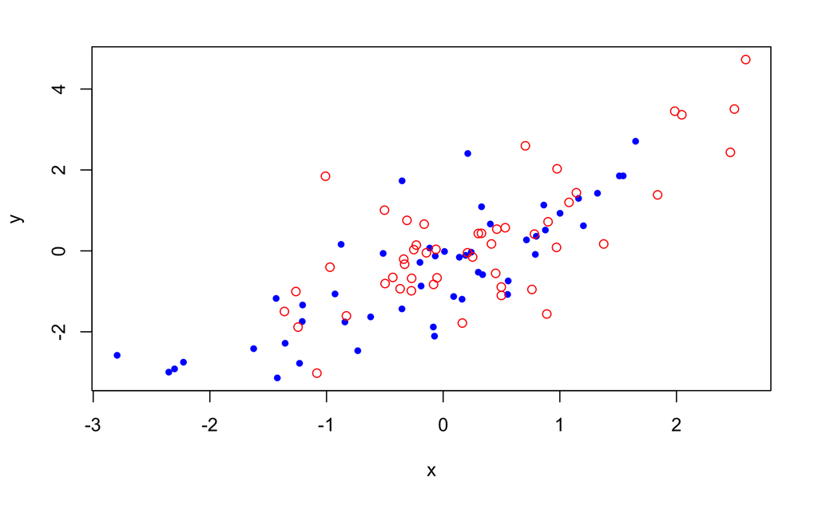

```r
points(x[g == "Female"], y[g == "Female"], col = "red")
```